# Final project

- Để biết sự khác biệt giữa mỗi nhóm có nhiều không chúng ta cần phải sử dụng kiểm tra thống kê

```r
aov(math_score ~ race.ethnicity, data = dt)
```

```
## Call:
##    aov(formula = math_score ~ race.ethnicity, data = dt)
##
## Terms:
##                 race.ethnicity Residuals
## Sum of Squares        12728.82 216960.26
## Deg. of Freedom              4       995
##
## Residual standard error: 14.76653
## Estimated effects may be unbalanced
```

- Nhìn vào kết quả trên, chúng ta chỉ có được thông tin chung, còn cần biết giá trị p để so sánh với mức ý nghĩa, và xem có cần bác bỏ H0 hay không.

```r
summary(aov(math_score ~ race.ethnicity, data = dt))
```

```
##                 Df Sum Sq Mean Sq F value   Pr(>F)
## race.ethnicity   4  12729    3182   14.59 1.37e-11 ***
## Residuals      995 216960     218
## ---
## Signif. codes:  0 '***' 0.001 '**' 0.01 '*' 0.05 '.' 0.1 ' ' 1
```

- Giá trị p nhỏ hơn ngưỡng thông thường là 0,05 nên chúng tôi bác bỏ H0.
- Kết luận: Có sự khác biệt thống kê giữa trung bình điểm toán trong mỗi sắc tộc chủng tộc.

1.2. Điểm môn toán so với trình độ học vấn của cha mẹ

- Phân tích dữ liệu

```r
by_parent_education <- dt %>%
  group_by(parental_level_of_education) %>%
  summarise(math_score_mean = mean(math_score), math_score_sd = sd(math_score)) %>% arrange(desc(math_score_mean))

by_parent_education
```

```
## # A tibble: 6 × 3
##   parental_level_of_education math_score_mean math_score_sd
##   <chr>                                 <dbl>         <dbl>
## 1 master's degree                        69.7          15.2
## 2 bachelor's degree                      69.4          14.9
## 3 associate's degree                     67.9          15.1
## 4 some college                           67.1          14.3
## 5 some high school                       63.5          15.9
## 6 high school                            62.1          14.5
```

Có một sự khác biệt nhỏ giữa phương tiện của mỗi nhóm (trình độ học vấn của cha mẹ). Tiếp theo, chúng ta có thể trực quan hóa dữ liệu của mình để hiểu rõ hơn.

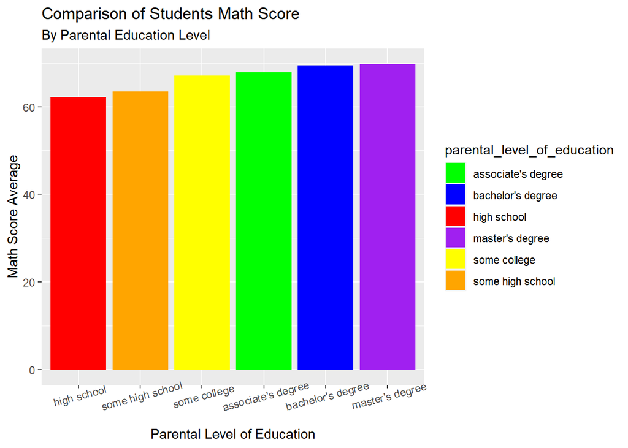

```r
ggplot(by_parent_education, aes(x = reorder(parental_level_of_education, math_score_mean),
                                y = math_score_mean, fill = parental_level_of_education)) +
                                geom_col() + ggtitle("Comparison of Students Math Score", subtitle = "By Parental Education Level") +                                          xlab("Parental Level of Education") + ylab("Math Score Average") +
                                theme(axis.text.x = element_text(angle = 15)) +
                                scale_fill_manual(values = c("green", "blue", "red", "purple", "yellow", "orange"))
```

- Dựa vào biểu đồ trên chúng ta có thể thấy trình độ học vấn của cha mẹ ảnh hưởng đến điểm môn toán như thế nào

- Đặt giá thiết:
- H0: Không có sự khác biệt về trung bình điểm môn toán giữa các bậc học của cha và mẹ
- H1: Có sự khác biệt về trung bình điểm môn toán giữa các bậc học của cha mẹ

```r
summary(aov(math_score ~ parental_level_of_education, data = dt))
```

```
##                              Df Sum Sq Mean Sq F value   Pr(>F)
## parental_level_of_education   5   7296  1459.1   6.522 5.59e-06 ***
## Residuals                   994 222394   223.7
## ---
## Signif. codes:  0 '***' 0.001 '**' 0.01 '*' 0.05 '.' 0.1 ' ' 1
```

- Giá trị p < 0,05, do đó bác bỏ giả thiết H0
- Có sự khác biệt đáng kể về điểm trung bình môn toán giữa trình độ học vấn của cha mẹ. Ví dụ, những học sinh có cha mẹ có bằng thạc sĩ đạt điểm môn toán cao hơn đáng kể so với những học sinh có cha mẹ chỉ mới tốt nghiệp trung học. Nhưng trình độ học vấn của cha mẹ không phải là yếu tố duy nhất vì còn có yếu tố khác như sắc tộc.
- Điểm môn Toán so với Trình độ học vấn của cha mẹ và Chủng tộc Dân tộc

```r
summary(aov(math_score ~ parental_level_of_education + race.ethnicity, data = dt))
```

```
##                              Df Sum Sq Mean Sq F value   Pr(>F)
## parental_level_of_education   5   7296  1459.1    6.84 2.77e-06 ***
## race.ethnicity                4  11193  2798.2   13.12 2.05e-10 ***
## Residuals                   990 211201   213.3
## ---
## Signif. codes:  0 '***' 0.001 '**' 0.01 '*' 0.05 '.' 0.1 ' ' 1
```

- Giá trị p < 0.05 do đó bác bỏ giả thiết H0
- Có một tác động đáng kể giữa điểm toán và trình độ học vấn của cha mẹ cũng như điểm toán và chủng tộc.

-Điểm môn toán so với sự kết hợp giữa trình độ học vấn của cha mẹ và chủng tộc

```r
summary(aov(math_score ~ parental_level_of_education:race.ethnicity, data = dt))
```

```
##                                             Df Sum Sq Mean Sq F value   Pr(>F)
## parental_level_of_education:race.ethnicity  29  19999   689.6    3.19 4.22e-08
## Residuals                                  970 209690   216.2
##
## parental_level_of_education:race.ethnicity ***
## Residuals
## ---
## Signif. codes:  0 '***' 0.001 '**' 0.01 '*' 0.05 '.' 0.1 ' ' 1
```

- Giá trị p < 0.05 do đó bác bỏ giả thiết H0
- Có một tác động đáng kể từ sự kết hợp giữa trình độ học vấn của cha mẹ và sắc tộc chủng tộc đối với điểm môn toán.
- Kết luận cuối cùng: Dựa vào những phân tích và đánh giá từ trên xuống chúng ta có thể thấy điểm số kiểm tra của môn toán cao hay thấp của mỗi sinh viên có liên quan đến quan hệ đáng kể giữa dân tộc, trình độ học vấn của cha mẹ